# IOH and dengue updates

Alyson Singleton

2024-01-22

# Summary

This analysis will investigate the effect of road building and paving on dengue and leishmaniasis—diseases transmitted by mosquitoes and sandfly vectors, respectively—in Peru’s Amazon basin. Building off of two months of field work in Summer 2022 that spurred a collaboration with Universidad Peruana Cayetano Heredia (UPCH) and the Regional Health Directorate of Madre de Dios (DIRESA, in Spanish), I plan to analyze how road quality upgrades drive changes in mobility through recently deforested areas, facilitating disease diffusion. A rapid paving of the Interoceanic Highway (2007-2009) throughout the region provides a unique opportunity to compare disease case data from health centers within 5km of the newly paved highway and those outside a 5km buffer before and after the highway was paved (a difference-in-differences causal inference approach). This work will include image classification analysis to create historical road development and quality datasets from satellite-imagery. I hypothesize that we will see dengue incidence increase almost immediately post paving (dengue produces highly localized outbreaks and responds directly to human movement), while leishmaniasis will not increase immediately post-paving and will act as a placebo (leishmaniasis transmission is affected more by frontier clearings and development of agricultural land).

# Background

#### Treatment cutoffs

A map of all spatial units in our region of interest ($n=70$), colored by treatment group options. All results in this document use a 5km cutoff, which results in 26 units in the treatment group and 44 in the control group. Tentatively, the results have not been sensitive to cutoff choice.

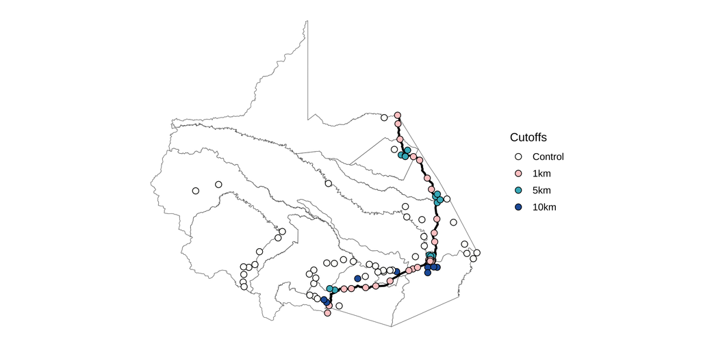

#### Dengue coverage

Bar plot showing how many spatial units had at least one case of dengue for each year in our data. Blue is “far” (control) and yellow is “near” (treatment).

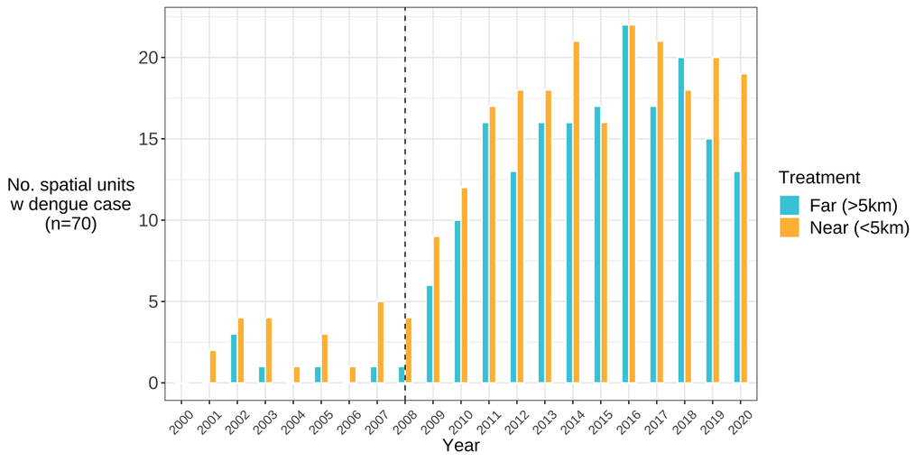

#### Leishmaniasis coverage

Bar plot showing how many spatial units had at least one case of leishmaniasis for each year in our data. Blue is “far” (control) and yellow is “near” (treatment).

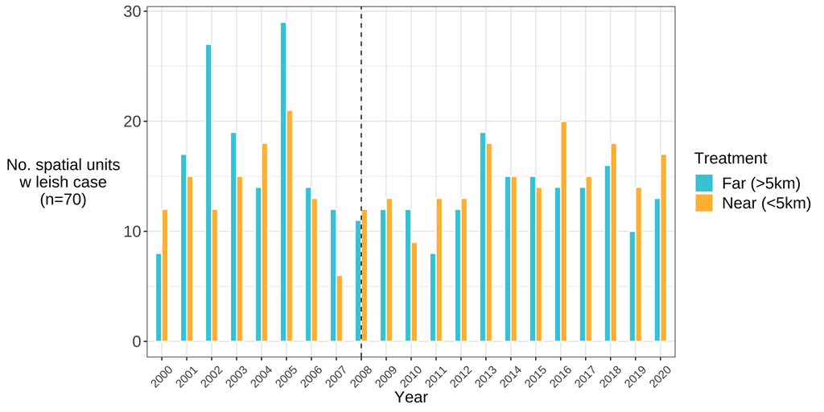

# Dengue results

## Yearly dengue incidence and population calculation

Raw data showing yearly dengue incidence in treatment (<5km) and control (>5km) groups. Vertical line is at 2008 (last year before hypothesized “shock”, i.e. the completed paving).

Yearly population data was calculated by combining remotely-sensed WorldPop population data (2000-2020) and health center surveillance data from DIRESA (2009-2017). All years with DIRESA data were kept, and all years without DIRESA data were filled in with adjusted WorldPop data. WorldPop data was adjusted by the average ratio between DIRESA and WorldPop data for each spatial unit for years where we had both DIRESA and WorldPop data. This adjusted population data is used for all of the following results.

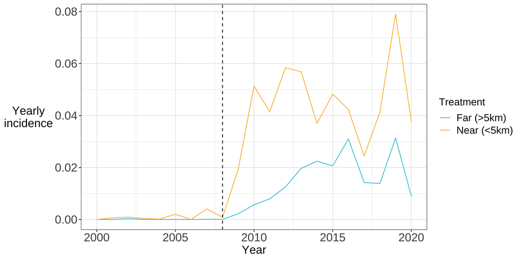

## Preliminary diff-in-diff results (yearly dengue model)

Each dot in this plot represents the beta coefficient for each year in the regression model, and the error bars display a 95% confidence interval. Each coefficient estimates the difference in yearly incidence between near and far healthcare centers for each year. If the hypothesis that the highway paving increased dengue transmission is correct, we should see the coefficients diverge from zero and become positive following 2008 (last year before hypothesized “shock”). Indeed, we see the coefficients diverge from zero starting in 2009 and generally increase over time. Additionally, all coefficients prior to 2009 are zero, which supports the parallel trends assumption. This model includes unit and year fixed effects, and standard errors are clustered at the unit and yearly levels (accounting for spatial and temporal autocorrelation). Notably, I have not yet included any additional control variables; I am considering adding precipitation and/or urban area.

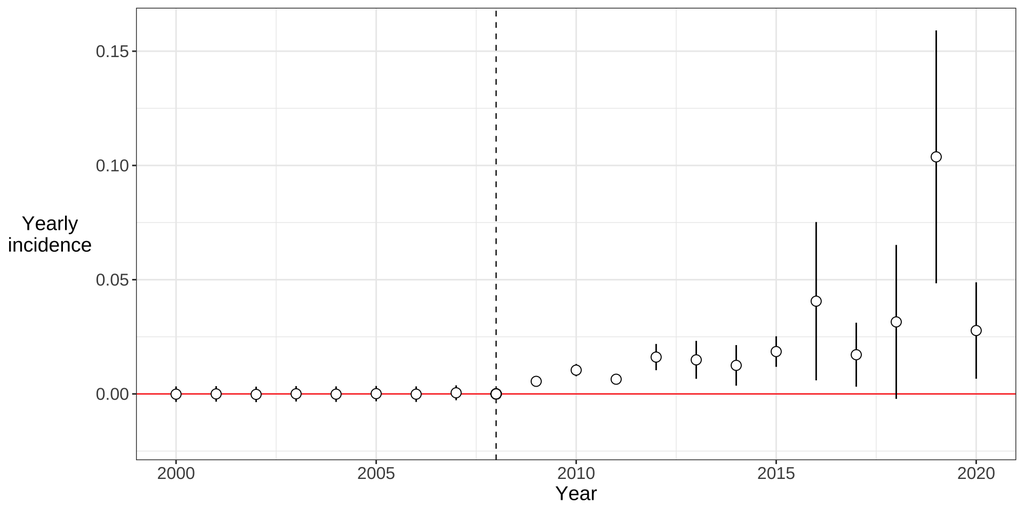

## Biannual dengue model

Raw data showing biannual dengue incidence in treatment (<5km) and control (>5km) groups. Vertical line is at 2008 (last year before hypothesized “shock”, i.e. the completed paving).

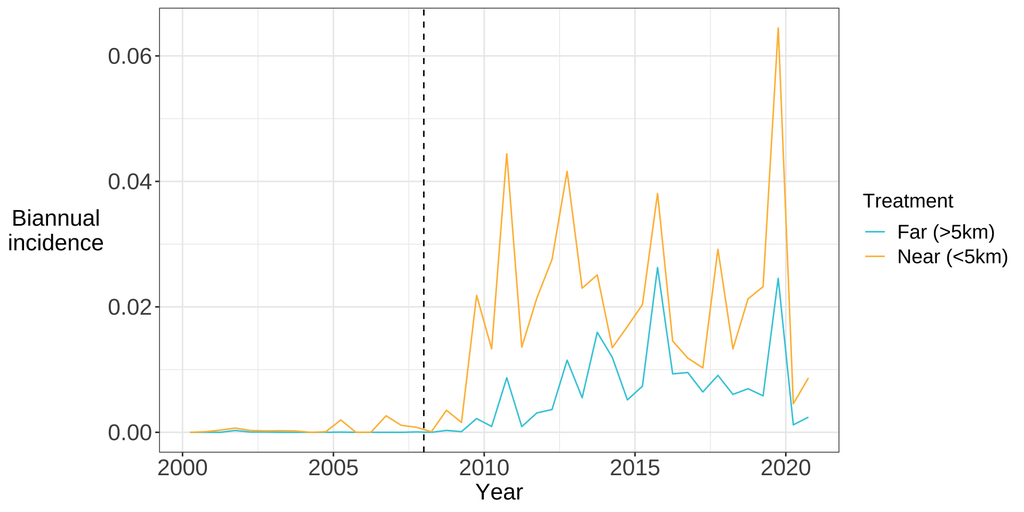

All the same as the description for the yearly model above, except for unit and biannual fixed effects and standard errors are clustered at the unit and biannual levels. I also colored the coefficients by rainy (red) or dry (white) season. The rainy season is regarded as the main dengue season in this region and runs from the beginning of October to the end of March.

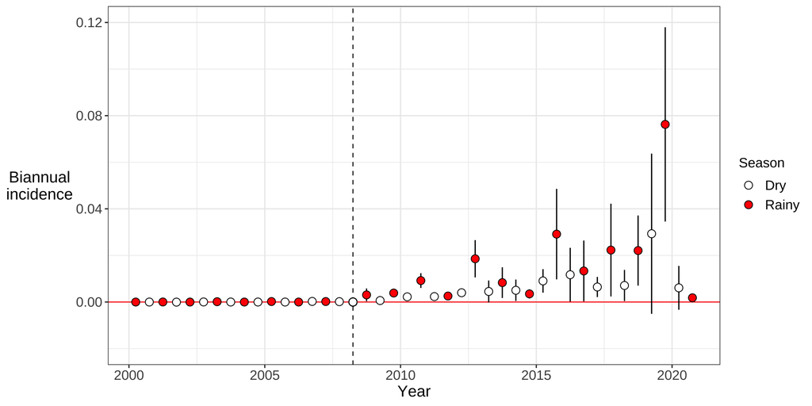

# Leish results

## Yearly leish incidence

Raw data showing yearly leishmaniasis incidence in treatment (<5km) and control (>5km) groups. Vertical line is at 2008 (last year before hypothesized “shock”, i.e. the completed paving).

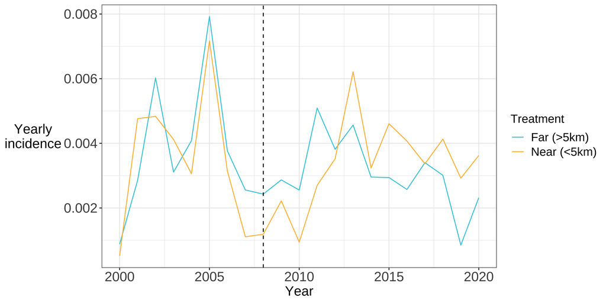

## Preliminary diff-in-diff results (yearly leish model)

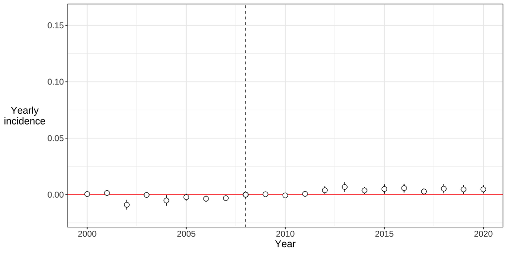

## Biannual leish model

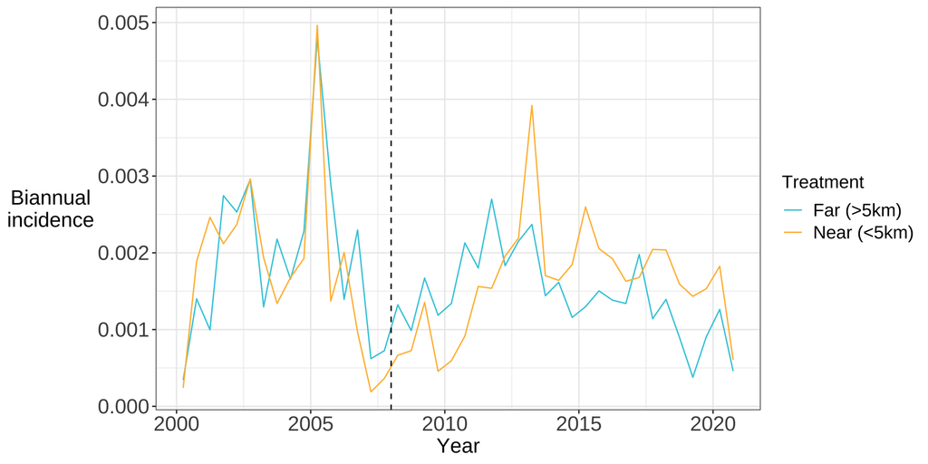

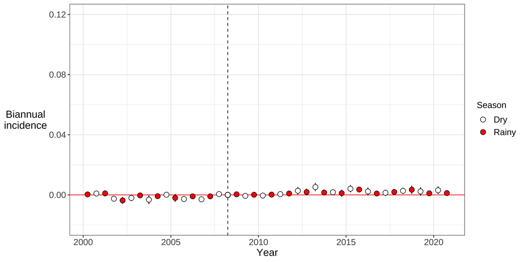

## Side by side plots to compare the disease systems

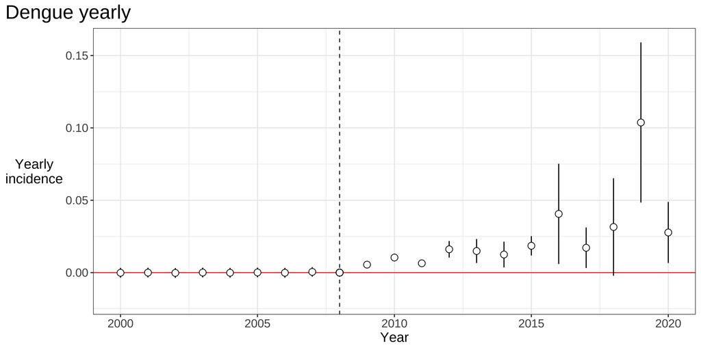

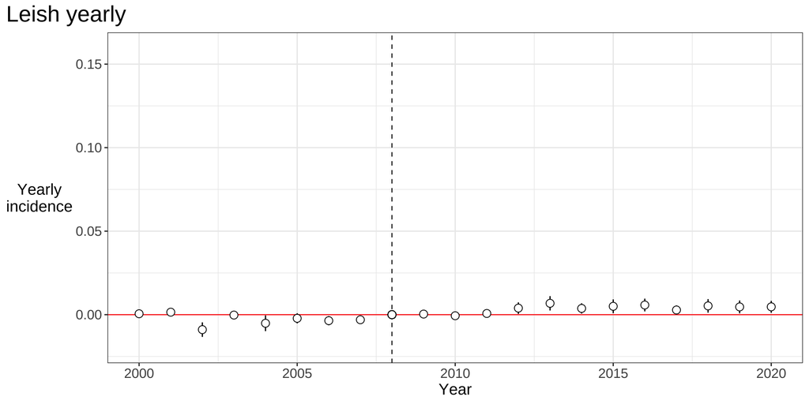

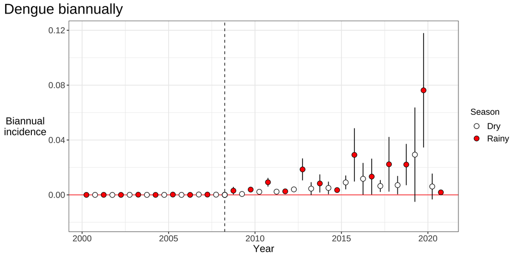

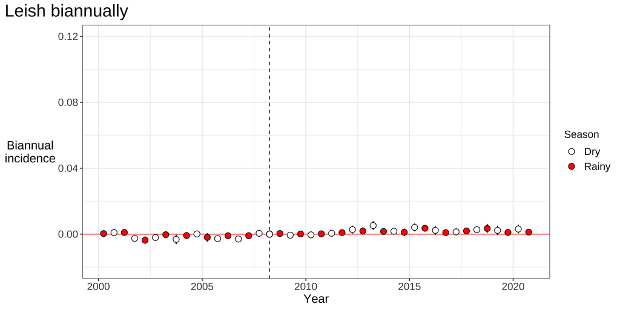